# 8 PROBABILISTIC REASONING OVER TIME

## 8.1 Temporal Probabilistic Model

### Temporal Probabilistic Model

#### Temporal Probabilistic Model

**Why do we need temporal probabilistic model**?

- The world changes over time (**random process**), and what happens now impacts what will happen in the future. We need to **track** and **predict** it
  - Stock market
  - Weather

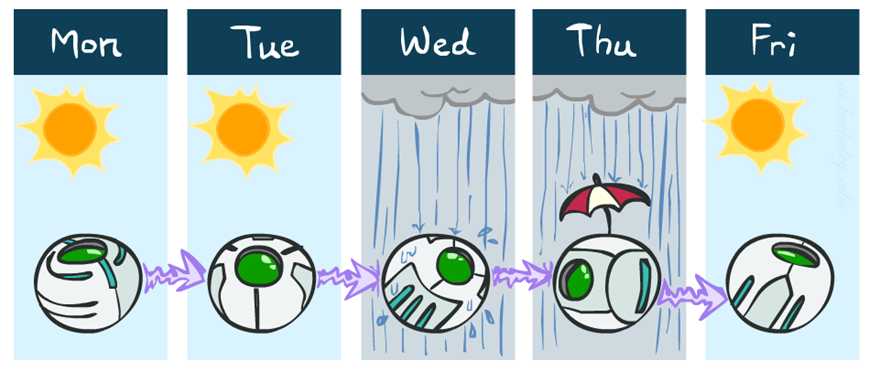

**How to model the time**?

- View the world as time slices: discrete time steps; step size depends on problem

[figure not shown]

- **State variables** $\boldsymbol{X}_{t}$ (often hidden): set of **unobservable state variables** at time $t$
  - State of the environment
  - Not directly observable but defines causal dynamics
- **Evidence variables** $\boldsymbol{E}_{t}$: set of **observable evidence variables** at time $t$
  - Caused by the state of the environment
- **Notation**: $\boldsymbol{X}_{a:b}=\boldsymbol{X}_{a},\boldsymbol{X}_{a+1},\ldots,\boldsymbol{X}_{b-1},\boldsymbol{X}_{b}$
- **Transition model**: How the world evolves
  $$\begin{equation}
  P(\boldsymbol{X}_{t}\mid\boldsymbol{X}_{0:t-1})
  \end{equation}$$
- **Sensor/observation model**: How the evidence variables get their values
  $$\begin{equation}
  P(\boldsymbol{E}_{t}\mid\boldsymbol{X}_{0:t},\boldsymbol{E}_{0:t-1})
  \end{equation}$$

### Markov process

#### Markov process

**Markov process** is a random process with **Markov assumption** “$\boldsymbol{X}_{t}$ depends on *bounded* subset of $\boldsymbol{X}_{0:t-1}$”

[figure not shown]

- **First-order Markov process**:
  $$\begin{equation}
  P(\boldsymbol{X}_{t}\mid\boldsymbol{X}_{0:t-1})=P(\boldsymbol{X}_{t}\mid\boldsymbol{X}_{t-1})
  \end{equation}$$
- **Second-order Markov process**:
  $$\begin{equation}
  P(\boldsymbol{X}_{t}\mid\boldsymbol{X}_{0:t-1})=P(\boldsymbol{X}_{t}\mid\boldsymbol{X}_{t-2},\boldsymbol{X}_{t-1})
  \end{equation}$$

[figure not shown]

- **Sensor Markov assumption**:
  $$\begin{equation}
  P(\boldsymbol{E}_{t}\mid\boldsymbol{X}_{0:t},\boldsymbol{E}_{0:t-1})=P(\boldsymbol{E}_{t}\mid\boldsymbol{X}_{t})
  \end{equation}$$
- **Stationary process**:
  - transition model $P(\boldsymbol{X}_{t}\mid\boldsymbol{X}_{t-1})$ fixed for all $t$
  - sensor model $P(\boldsymbol{E}_{t}\mid\boldsymbol{X}_{t})$ fixed for all $t$

#### Example

[figure not shown]

- First-order Markov assumption may not be exactly true in real world!
- Possible fixes:
  1. **Increase order** of Markov process
  2. **Augment state**, e.g., add $Temp_{t}$, $Pressure_{t}$

## 8.2 Inference in Temporal Models

#### Inference tasks

- **Filtering**: computing the **belief state**, the posterior distribution over the most recent state given all evidence to date
  $$P(X_{t}\mid e_{1:t})$$
- **Prediction**: computing the posterior distribution over the future state, given all evidence to date
  $$P(X_{t+k}\mid e_{1:t})\text{ for }k>0$$
- **Smoothing**: computing the posterior distribution over a past state, given all evidence up to the present.
  $$P(X_{k}\mid e_{1:t})\text{ for }0\leq k<t$$
- **Most likely explanation**: given a sequence of observations, find the sequence of states that is most likely to have generated those observations
  $$\arg\max_{x_{1:t}}P(x_{1:t}\mid e_{1:t})$$

### Filtering

#### Filtering

- Given the result of filtering up to time $t$, we needs to compute the result for $t+1$ from the new evidence $e_{t+1}$,
  $$\begin{align}
  P(X_{t+1}\mid e_{1:t+1}) & = & P(X_{t+1}\mid e_{1:t},e_{t+1})\\
  & = & \alpha P(e_{t+1}\mid X_{t+1},e_{1:t})P(X_{t+1}\mid e_{1:t})\\
  & = & \alpha P(e_{t+1}\mid X_{t+1})P(X_{t+1}\mid e_{1:t})
  \end{align}$$
- We obtain the one-step prediction for the next state by conditioning on the current state $X_{t}$:
  $$\begin{align}
  P(X_{t+1}\mid e_{1:t+1}) & = & \alpha P(e_{t+1}\mid X_{t+1})\sum_{x_{t}}P(X_{t+1}\mid x_{t},e_{1:t})P(x_{t}\mid e_{1:t})\nonumber \\
  & = & \alpha P(e_{t+1}\mid X_{t+1})\sum_{x_{t}}P(X_{t+1}\mid x_{t})P(x_{t}\mid e_{1:t})
  \end{align}$$
- The process is given by

$f_{1:t+1}=\text{Forward}(f_{1:t},e_{t+1})$ where $f_{1:t}=P(X_{t}\mid e_{1:t})$

#### Filtering example

[figure not shown]

### Smoothing

#### Smoothing

[figure not shown]

- Divide evidence $e_{1:t}$ into $e_{1:k}$, $e_{k+1:t}$:
  $$\begin{align}
  P(X_{k}\mid e_{1:t}) & = & P(X_{k}\mid e_{1:k},e_{k+1:t})\nonumber \\
  & = & \alpha P(X_{k}\mid e_{1:k})P(e_{k+1:t}\mid X_{k},e_{1:k})\nonumber \\
  & = & \alpha P(X_{k}\mid e_{1:k})P(e_{k+1:t}\mid X_{k})\nonumber \\
  & = & \alpha f_{1:k}b_{k+1:t}
  \end{align}$$
- Backward message computed by a backwards recursion:
  $$\begin{align}
  P(e_{k+1:t}\mid X_{k}) & = & \sum_{x_{k+1}}P(e_{k+1:t}\mid X_{k},x_{k+1})P(x_{k+1}\mid X_{k})\nonumber \\
  & = & \sum_{x_{k+1}}P(e_{k+1:t}\mid x_{k+1})P(x_{k+1}\mid X_{k})\nonumber \\
  & = & \sum_{x_{k+1}}P(e_{k+1}\mid x_{k+1})P(e_{k+2:t}\mid x_{k+1})P(x_{k+1}\mid X_{k})
  \end{align}$$
- The process is given by

$b_{k+1:t}=\text{Backward}(b_{k+2:t},e_{t+1})$ where $b_{k+1:t}=P(e_{k+1:t}\mid X_{k})$

#### Smoothing example

[figure not shown]

- **Forward–backward** algorithm: cache forward messages along the way

  Time linear in $t$ (polytree inference), space $O(t\left|f\right|)$

### Most likely explanation

#### Most likely explanation

- Most likely sequence $\neq$ sequence of most likely states!
- Most likely path to each $x_{t+1}$ = most likely path to *some* $x_{t}$ plus one more step

$$\begin{aligned} & \max P(x_{1},\ldots,x_{t},X_{t+1}\mid e_{1:t+1})\\
& =P(e_{t+1}\mid X_{t+1})\max_{x_{t}}\left(P(X_{t+1}\mid x_{t})\max_{x_{1}\ldots x_{t-1}}P(x_{1},\ldots,x_{t-1},x_{t}\mid e_{1:t})\right)
\end{aligned}$$

- Identical to filtering, except $f_{1:t}$ replaced by
  $$m_{1:t}=\max_{x_{1}\ldots x_{t-1}}P(x_{1},\ldots,x_{t-1},X_{t}\mid e_{1:t}),$$
  I.e., $m_{1:t}(i)$ gives the probability of the most likely path to state $i$.
- Update has sum replaced by max, giving the **Viterbi algorithm**:
  $$m_{1:t+1}=P(e_{t+1}\mid X_{t+1})\max_{x_{t}}\left(P(X_{t+1}\mid x_{t})m_{1:t}\right)$$

#### Viterbi example

[figure not shown]

## 8.3 Hidden Markov Models

### Example

#### Problem

Consider a temporal probabilistic model with two random variables

- Weather: *sunny* or *rainny*
- Baby: *happy* or *sad*

[figure not shown]

#### Data

- Complete observations in 15 days

[figure not shown]

- Partial observations in 15 days

[figure not shown]

#### Markov Model

- Markov model with the following assumptions
  - Transition probabilities
    $$P(weather_{t+1}\mid weather_{t})$$
  - Emission probabilities
    $$P(baby_{t}\mid weather_{t})$$

[figure not shown]

#### Questions

**Learning**

1. How did we find these probabilities?

**Inference**

1. What’s the probability that a random day is Sunny or Rainy?
2. If Baby is Happy today, what’s the probability that it’s Sunny or Rainy?
3. If for three days Baby is Happy, Sad, Happy, what was the weather?

#### How did we find these probabilities?

- Transition probabilities

[figure not shown]

- Emission probabilities

[figure not shown]

#### Sunny or Rainny

[figure not shown]

- We have the equations
  $$\begin{align*}
  S & =0.8S+0.4R\\
  R & =0.2S+0.6R
  \end{align*}$$
- Solve the equations
  $$\begin{align*}
  S & =2/3\\
  R & =1/3
  \end{align*}$$

#### Today, Baby is happy

[figure not shown]

#### What was the weather?

- If for two days Baby is Happy, Sad, what was the weather?

[figure not shown]

- If for three days Baby is Happy, Sad, Happy, what was the weather?

[figure not shown]

#### Viterbi algorithm

[figure not shown]

### Hidden Markov Models

#### Hidden Markov models

**Hidden Markov model** is a temporal probabilistic model where $X_{t}$ is a single, discrete variable (usually $E_{t}$ is too) and domain of $X_{t}$ is $\{1,\ldots,S\}$

- **Transition matrix** **$T_{ij}$** for each time step
  $$T_{ij}=P(X_{t}=j\mid X_{t-1}=i)$$
- **Sensor matrix** $O_{t}$ for each time step, diagonal elements
  $$P(e_{t}\mid X_{t}=i)$$
- For example, $T=\left(\begin{array}{cc} 0.7 & 0.3\\ 0.3 & 0.7 \end{array}\right)$, $O=\left(\begin{array}{cc} 0.9 & 0\\ 0 & 0.2 \end{array}\right)$ or $\left(\begin{array}{cc} 0.1 & 0\\ 0 & 0.8 \end{array}\right)$

#### Forward-backward messages

- Forward and backward messages as column vectors:
  $$\begin{align}
  f_{1:t+1} & = & \alpha O_{t+1}T^{\intercal}f_{1:t}\\
  b_{k+1:t} & = & TO_{k+1}b_{k+2:t}
  \end{align}$$
- Forward-backward algorithm needs time $O(S^{2}t)$ and space $O(St)$

#### Country dance algorithm

Can avoid storing all forward messages in smoothing by running forward algorithm backwards:
$$\begin{align}
f_{1:t+1} & = & \alpha O_{t+1}T^{\intercal}f_{1:t}\\
O_{t+1}^{-1}f_{1:t+1} & = & \alpha T^{\intercal}f_{1:t}\\
\alpha'(T^{\intercal})^{-1}O_{t+1}^{-1}f_{1:t+1} & = & f_{1:t}
\end{align}$$
Algorithm: forward pass computes $f_{t}$, backward pass does $f_{i}$, $b_{i}$

[figure not shown]

## 8.4 Kalman Filters

#### Kalman filters

**Kalman Filter** is a temporal probabilistic model that represents systems described by a set of continuous variables with **assumption**s: Gaussian prior, linear Gaussian transition model and sensor model

- Tracking a bird flying
  $$\boldsymbol{X}_{t}=(position,velocity)=\left(x,y,z,\dot{x},\dot{y},\dot{z}\right)$$

[figure not shown]

#### Updating Gaussian distributions

**Prediction step**:

- If $P(X_{t}\mid e_{1:t})$ is Gaussian and the transition model $P(X_{t+1}\mid x_{t})$ is linear Gaussian, then prediction
  $$P(X_{t+1}\mid e_{1:t})=\int_{x_{t}}P(X_{t+1}\mid x_{t})P(x_{t}\mid e_{1:t})\,dx_{t}$$
  is Gaussian.
- If $P(X_{t+1}\mid e_{1:t})$ is Gaussian and the sensor model $P(e_{t+1}|X_{t+1})$ is linear Gaussian, then the updated distribution
  $$P(X_{t+1}\mid e_{1:t+1})=\alpha P(e_{t+1}\mid X_{t+1})P(X_{t+1}\mid e_{1:t})$$
  is Gaussian
- Hence $P(X_{t}\mid e_{1:t})$ is multivariate Gaussian $\mathcal{N}(\boldsymbol{\mu}_{t},\Sigma_{t})$ for all $t$

#### Simple 1-D example

- Gaussian random walk on $X$–axis, transition s.d. $\sigma_{x}$, sensor s.d. $\sigma_{z}$
  $$\begin{align*}
  \mu_{t+1} & =\frac{(\sigma_{t}^{2}+\sigma_{x}^{2})z_{t+1}+\sigma_{z}^{2}\mu_{t}}{\sigma_{t}^{2}+\sigma_{x}^{2}+\sigma_{z}^{2}}\\
  \sigma_{t+1}^{2} & =\frac{(\sigma_{t}^{2}+\sigma_{x}^{2})\sigma_{z}^{2}}{\sigma_{t}^{2}+\sigma_{x}^{2}+\sigma_{z}^{2}}
  \end{align*}$$

[figure not shown]

#### General Kalman update

- Transition and sensor models:
  $$\begin{equation}
  \begin{array}{rcl}
  P(\boldsymbol{x}_{t+1}\mid\boldsymbol{x}_{t}) & = & \mathcal{N}(F\boldsymbol{x}_{t},\Sigma_{x})(\boldsymbol{x}_{t+1})\\
  P(\boldsymbol{z}_{t}\mid\boldsymbol{x}_{t}) & = & \mathcal{N}(H\boldsymbol{x}_{t},\Sigma_{z})(\boldsymbol{z}_{t})
  \end{array}
  \end{equation}$$

  $F$ is the matrix for the transition; $\Sigma_{x}$ the transition noise covariance

  $H$ is the matrix for the sensors; $\Sigma_{z}$ the sensor noise covariance
- Filter computes the following update:
  $$\begin{equation}
  \begin{array}{rcl}
  \boldsymbol{\mu}_{t+1} & = & F\boldsymbol{\mu}_{t}+K_{t+1}(\boldsymbol{z}_{t+1}-HF\boldsymbol{\mu}_{t})\\
  \Sigma_{t+1} & = & (I-K_{t+1})(F\Sigma_{t}F^{\intercal}+\Sigma_{x})
  \end{array}
  \end{equation}$$
  where $K_{t+1}=(F\Sigma_{t}F^{\intercal}+\Sigma_{x})H^{\intercal}(H(F\Sigma_{t}F^{\intercal}+\Sigma_{x})H^{\intercal}+\Sigma_{z})^{-1}$ is the **Kalman gain matrix**
- $\Sigma_{t}$ and $K_{t}$ are independent of observation sequence, so compute offline

#### 2-D tracking example

[figure not shown]

#### 2-D tracking example: filtering

[figure not shown]

#### 2-D tracking example: smoothing

[figure not shown]

#### Where it breaks

- Cannot be applied if the transition model is nonlinear
- **Extended Kalman Filter** models transition as *locally linear* around $x_{t}=\boldsymbol{\mu}_{t}$
  - Fails if systems is locally unsmooth

[figure not shown]

## 8.5 Dynamic Bayesian Networks

#### Dynamic Bayesian networks

- $X_{t}$, $E_{t}$ contain arbitrarily many variables in a replicated Bayes net

[figure not shown]

#### DBNs vs. HMMs

- Every HMM is a single-variable DBN; every discrete DBN is an HMM

[figure not shown]

- Sparse dependencies $\Rightarrow$ exponentially fewer parameters;

  e.g., 20 state variables, three parents each
- DBN has $20\times2^{3}=160$ parameters, HMM has $2^{20}\times2^{20}\approx10^{12}$

#### DBNs vs Kalman filters

- Every Kalman filter model is a DBN, but few DBNs are KFs; real world requires non-Gaussian posteriors

  E.g., where are bin Laden and my keys? What’s the battery charge?

[figure not shown]

#### Exact inference in DBNs

- Naive method: **unroll** the network and run any exact algorithm

[figure not shown]

- Problem: inference cost for each update grows with $t$
- **Rollup filtering**: add slice $t+1$, “sum out” slice $t$ using variable elimination
- Largest factor is $O(d^{n+1})$, update cost $O(d^{n+2})$ (cf. HMM update cost $O(d^{2n})$)

#### Likelihood weighting for DBNs

- Set of weighted samples approximates the belief state

[figure not shown]

- LW samples pay no attention to the evidence!

  $\Rightarrow$ fraction “agreeing” falls exponentially with $t$

  $\Rightarrow$ number of samples required grows exponentially with $t$

[figure not shown]

### Particle Filtering

#### Particle filtering

**Particle filtering** is a model to focus on the population of samples (“particles”) that tracks the high-likelihood regions of the state-space

[figure not shown]

- Widely used for tracking nonlinear systems, esp. in vision
- Also used for simultaneous localization and mapping in mobile robots $10^{5}$-dimensional state space

#### Filter task

Writing $N(\boldsymbol{x}_{t}\mid\boldsymbol{e}_{1:t})$ for the number of samples occupying state $\boldsymbol{x}_{t}$ after observations $\boldsymbol{e}_{1:t}$ have been processed. Assume consistent at time $t$:
$$\begin{equation}
N(\boldsymbol{x}_{t}\mid\boldsymbol{e}_{1:t})/N=P(\boldsymbol{x}_{t}\mid\boldsymbol{e}_{1:t})
\end{equation}$$

- **Propagate** forward populations of $\boldsymbol{x}_{t+1}$:
  $$\begin{equation}
  N(\boldsymbol{x}_{t+1}\mid\boldsymbol{e}_{1:t})=\sum_{x_{t}}P(\boldsymbol{x}_{t+1}\mid\boldsymbol{x}_{t})N(\boldsymbol{x}_{t}\mid\boldsymbol{e}_{1:t})
  \end{equation}$$
- **Weight** samples by their likelihood for $\boldsymbol{e}_{t+1}$:
  $$\begin{equation}
  W(\boldsymbol{x}_{t+1}\mid\boldsymbol{e}_{1:t+1})=P(\boldsymbol{e}_{t+1}\mid\boldsymbol{x}_{t+1})N(\boldsymbol{x}_{t+1}\mid\boldsymbol{e}_{1:t})
  \end{equation}$$
- **Resample** to obtain populations proportional to $W$:
  $$\begin{align}
  N(\boldsymbol{x}_{t+1}\mid\boldsymbol{e}_{1:t+1})/N & = & \alpha W(\boldsymbol{x}_{t+1}\mid\boldsymbol{e}_{1:t+1})\nonumber \\
  & = & \alpha P(\boldsymbol{e}_{t+1}\mid\boldsymbol{x}_{t+1})N(\boldsymbol{x}_{t+1}\mid\boldsymbol{e}_{1:t})\nonumber \\
  & = & \alpha P(\boldsymbol{e}_{t+1}\mid\boldsymbol{x}_{t+1})\sum_{x_{t}}P(\boldsymbol{x}_{t+1}\mid x_{t})N(\boldsymbol{x}_{t}\mid\boldsymbol{e}_{1:t})\nonumber \\
  & = & \alpha P(\boldsymbol{e}_{t+1}\mid\boldsymbol{x}_{t+1})\sum_{x_{t}}P(\boldsymbol{x}_{t+1}\mid\boldsymbol{x}_{t})P(\boldsymbol{x}_{t}\mid\boldsymbol{e}_{1:t})\nonumber \\
  & = & P(\boldsymbol{x}_{t+1}\mid\boldsymbol{e}_{1:t+1})
  \end{align}$$

#### Particle filtering performance

- Approximation error of particle filtering remains bounded over time, at least empirically—theoretical analysis is difficult

[figure not shown]

## 8.6 Keeping Track of Many Objects

#### Summary

- Temporal models use state and sensor variables replicated over time
- Markov assumptions and stationarity assumption, so we need
  - transition model $P(X_{t}\mid X_{t-1})$
  - sensor model $P(E_{t}\mid X_{t})$
- Tasks are filtering, prediction, smoothing, most likely sequence; *all done recursively with constant cost per time step*
- Hidden Markov models have a single discrete state variable; used for speech recognition
- Kalman filters allow $n$ state variables, linear Gaussian, $O(n^{3})$ update
- Dynamic Bayes nets subsume HMMs, Kalman filters; exact update intractable
- Particle filtering is a good approximate filtering algorithm for DBNs

## 8.7 References